# Data audit

What the four Vizathon files contain, how they join, and what the pipeline must handle

Author

Michael Davies

Published

16 October 2026

The Chelsea FC Performance Insights Vizathon 2025 dataset contains **simulated data for one player** across four files. This audit records what each file holds, checks it against the data guide and against itself, and sets out the cleaning rules the pipeline will follow. Every number below is calculated from the data when this report renders.

4 files, all keyed by date

620 days where all three daily sources overlap

20 checks run: 5 pass, 11 notes, 4 issues

73% of capability rows are carried forward, not new tests

## Summary

The data is clean in the ways that matter most for joining: every file has exactly one row per date (and per test or metric), dates parse without error, and missing values are recorded consistently. Three things need handling before analysis:

1. **Most capability rows are repeats.** The file carries each result forward daily until the next test, so 73% of rows are copies. Trends and test counts must use only the 832 genuine results.
2. **GPS speed bands are not always nested.** In 91 of 721 sessions, distance above a higher speed threshold exceeds distance above a lower one. Bands should be reported as given, never subtracted from each other.
3. **One priority-area status doesn’t match the data.** The sprint target is marked “Achieved”, but the latest measured score sits just below the 65% threshold. A tracker built on this data should calculate status, not copy it.

## Coverage

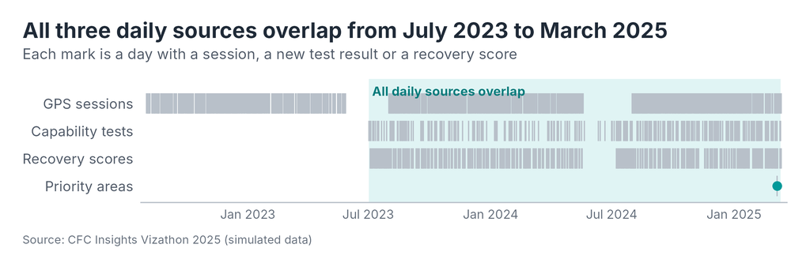

GPS covers three seasons; capability and recovery cover two. Analysis that combines sources should use the overlap window from 2 July 2023 to 12 March 2025. GPS has no data in June or July, so pre-season appears only in the recovery and capability files.

## All checks

| File | Check | Affected | Status | What it means |
| --- | --- | --- | --- | --- |
| GPS | One row per date | None | Pass | Each date appears once, so date is a safe join key. |
| GPS | Dates parse as day/month/year | None | Pass | All dates valid. |
| GPS | Days with no session recorded | 141 of 862 | Note | Every calendar day has a row; days off are rows of zeros, not missing rows. Exclude them from averages. |
| GPS | Match days with no data | 3 of 147 | Note | All three fall in a 29-day block of zeros from 14 March 2025, which suggests a period of unavailability rather than errors. |
| GPS | Speed bands are nested (>27 within >24 within >21 km/h) | 91 of 721 | Issue | Higher-speed distance sometimes exceeds the band below it, which cannot happen if the bands are cumulative. Treat bands as approximate and avoid subtracting them to make zones. |
| GPS | Acceleration bands are nested | 3 of 721 | Issue | A handful of sessions have more efforts above 4.5 m/s² than above 3.5 m/s². |
| GPS | Effort counts are whole numbers | 721 of 721 | Note | Counts are fractional, a sign of simulation. Round for display only. |
| GPS | Heart rate time fits within session duration | 13 of 721 | Note | Time in HR zones exceeds session duration by more than 10% in a few sessions. HR may be recorded over a longer window. |
| GPS | Continuous daily coverage in season | 2 of 861 | Note | Daily from 1 August to 31 May each season; June and July are absent, so there is no GPS pre-season data. |
| Capability | One row per date and test combination | None | Pass | 20 movement, quality and expression combinations every day. |
| Capability | Rows that are carried forward, not new results | 9,007 of 12,400 | Issue | Values repeat until a new test, as the guide says. Use only new results for trends and test counts, or trends will look smoother and more frequent than they are. |
| Capability | Missing benchmark scores | 2,561 of 12,400 | Note | Missing where there is not yet enough data for a benchmark, mostly isometric tests early on. |
| Capability | Scores outside 0–100% | 389 of 9,839 | Note | Benchmark scores can exceed 100% or fall below 0, so they are relative scores rather than percentiles. Do not cap them. |
| Recovery | One row per date and metric | None | Pass | 13 metrics every day: 6 categories with 2 metrics each, plus the overall score. |
| Recovery | Completeness of 0 always means no composite score | None | Pass | Consistent: a composite exists only on days its tests were completed. |
| Recovery | Days with an overall recovery score | 371 of 621 | Note | The overall score exists on 60% of days. Missing means not collected, not zero. |
| Recovery | Overall score equals the mean of the category composites | 282 of 371 | Note | The overall score tracks the category mean but is not equal to it, so its weighting is unknown. Use it as supplied rather than recomputing it. |
| Priorities | Review dates fall within the data | 3 of 3 | Note | All three targets are reviewed on 7 May 2025, after the capability and recovery data end on 12 March 2025. |
| Priorities | Targets can be measured from the data | 2 of 3 | Note | Sleep is recorded as a relative quality score, not hours, and nutrition is not recorded at all. Only the sprint target maps to a measured score. |
| Priorities | Sprint target status matches the data | 1 of 1 | Issue | Marked “Achieved” (>65% max velocity score), but the latest dynamic max velocity score is 64.65% on 12 March 2025. |

## The files

### GPS

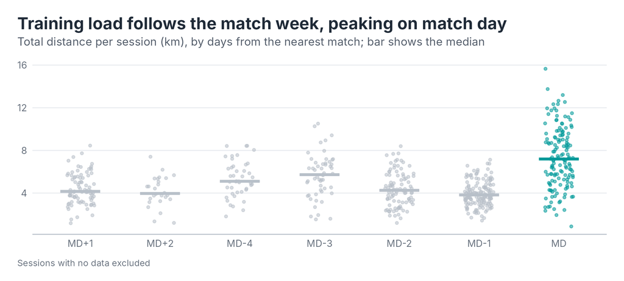

862 rows, one per calendar day from 2 August 2022 to 11 April 2025, including 147 match days. Days without a session are stored as rows of zeros (141 days), so averages must exclude them. Match-day codes count up to 10 in both directions and stop there, so “10” means “10 or more”. Heart rate zones arrive as minutes and seconds; the reader converts them to minutes.

### Physical capability

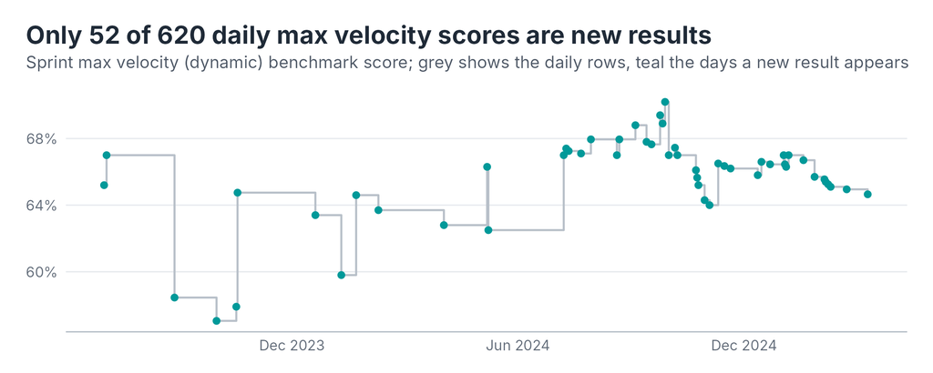

12,400 rows: 20 combinations of movement (agility, jump, sprint, upper body), quality and expression (isometric or dynamic), every day from 2 July 2023 to 12 March 2025. The score is a benchmark percentage that can exceed 100% or fall below 0. Across all combinations there are 832 genuine results on 252 test days.

### Recovery status

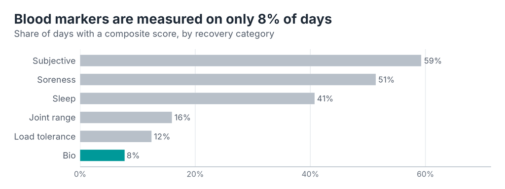

8,073 rows in long format: 13 metrics a day from 2 July 2023 to 13 March 2025. Each of six categories has a completeness score (0 to 1) and a composite score relative to the player’s norm, plus one overall score. Missing means not collected; zero is a real zero. Infrequent tests such as blood markers will need carrying forward, with their age shown, if they are to sit on a daily view.

### Individual priority areas

| Priority | Area | Target | Type | Period | Tracking | Measurable here |
| --- | --- | --- | --- | --- | --- | --- |
| 1 | Sleep | Increase average sleep by 1hr per night | Habit | 7 Mar to 7 May 2025 | On Track | Partly: sleep is a quality score, not hours |
| 2 | Nutrition | 45g of carbohydrate every half time | Habit | 7 Mar to 7 May 2025 | On Track | No: nutrition is not recorded |
| 3 | Sprint | >65% in max velocity score | Outcome | 7 Mar to 7 May 2025 | Achieved | Yes: sprint max velocity benchmark |

Three targets set on 7 March 2025 for review on 7 May 2025, after the other data ends. Only the sprint target can be checked against measured data.

## How the files join

All four files describe one player, so **date is the only join key**. The GPS and recovery files have one row per day and join directly; capability joins on date once reduced to new results; priority areas apply to a date range rather than a single day.

| From | To | Key | Notes |
| --- | --- | --- | --- |
| GPS | Recovery | `date` | 529 GPS days in the overlap, all with a recovery row |
| GPS | Capability | `date` = `test_date` | Join to the most recent result on or before each date |
| Any | Priority areas | `date` between `target_set` and `review_date` | Three targets, one shared period |

## Rules for the pipeline

1. Read the GPS file as Latin-1, and parse all dates as day/month/year.
2. Keep GPS rows of zeros as days without a session; exclude them from averages and load totals.
3. Treat match-day code 10 as “10 or more” and derive match context from `md_plus_code == 0`.
4. Report speed and acceleration bands as supplied; never subtract one band from another.
5. Reduce capability data to new results before calculating trends, test frequency or change.
6. Keep benchmark scores uncapped; they are relative scores, not percentiles.
7. Treat missing recovery values as not collected; keep zeros as measured values.
8. Use the overall recovery score as supplied rather than recomputing it.
9. Restrict combined analyses to the overlap window, 2 July 2023 to 12 March 2025.
10. Calculate priority-area status from the data where it can be measured, and show where it can’t.

Data: CFC Insights Vizathon 2025, Chelsea FC Performance Insights (simulated data for one player). Raw files are downloaded from the public competition repository, not stored here.